# Impact of nutrients on species presence

The goal of this notebook is to quantify the impact of nutrient enrichment on the presence of fish species in rivers, as done for large dams in D12. To do so, we need to

- get the river nutrient measurements from NAIADES
- match the nutrient measurements to the fishing operations (space and time)
- model the effect of nutrients on the presence of each species

## Setup

```r
library(renv)
renv::load()
library(targets)
library(here)
tar_config_set(
  store = here::here("_targets")
)
library(ggplot2)
library(dplyr)
devtools::load_all()
nice_theme()
```

## Nutrient data

### Presentation

The chemical measurements of rivers come from the NAIADES database, downloaded with the Hub’Eau API (target `naiades_pc`). We focus on 9 parameters:

- **ammonium** (NH₄⁺): reduced nitrogen, mostly from wastewater and manure; toxic to fish in its un-ionised form (NH₃) at high pH and temperature
- **nitrite** (NO₂⁻): intermediate of the oxidation of ammonium into nitrate, toxic to fish at low concentrations
- **nitrate** (NO₃⁻): oxidised nitrogen, mostly from agricultural leaching
- **Kjeldahl nitrogen** (NKj): organic nitrogen plus ammonium
- **orthophosphate** (PO₄³⁻): dissolved phosphorus directly available to algae
- **total phosphorus** (Ptot): dissolved and particulate phosphorus, expressed as P
- **temperature** (°C)
- **dissolved oxygen** (O₂, mg/L)
- **oxygen saturation** (%): dissolved oxygen relative to the saturation concentration at the water temperature and pressure.

The measurements run from 2000 to 2021. We keep the stations of the four watersheds (districts) retained for the study. Each measurement comes with:

- **fraction analysed:** raw water, filtered water, sediments…
- **unit:** unit of the measurement value
- **remark code:** indicating for example if the value is below the quantification limit.

```r
naiades <- tar_read(naiades_pc)
naiades_parameter <- tar_read(naiades_parameter)
parameter_name <- setNames(names(naiades_parameter), naiades_parameter)
naiades <- mutate(naiades, parameter = factor(parameter_name[code_parametre], parameter_name))
```

### Coverage

Here is for each parameter: number of measurements, stations, and years covered.

```r
naiades |>
  summarise(
    measurements = n(),
    stations = n_distinct(code_station),
    first = min(format(date, "%Y")),
    last = max(format(date, "%Y")),
    .by = parameter
  ) |>
  arrange(parameter) |>
  knitr::kable(format.args = list(big.mark = ","))
```

| parameter | measurements | stations | first | last |
| --- | --- | --- | --- | --- |
| ammonium | 721,024 | 10,214 | 2000 | 2021 |
| nitrite | 698,390 | 9,961 | 2000 | 2021 |
| nitrate | 753,995 | 10,712 | 2000 | 2021 |
| orthophosphate | 723,047 | 9,811 | 2000 | 2021 |
| total_phosphorus | 732,455 | 10,313 | 2000 | 2021 |
| kjeldahl_nitrogen | 664,887 | 9,619 | 2000 | 2021 |
| temperature | 913,855 | 10,245 | 2000 | 2021 |
| oxygen | 900,497 | 10,249 | 2000 | 2021 |
| oxygen_saturation | 887,901 | 10,078 | 2000 | 2021 |

### Fraction analysed

Share of the measurements per fraction analysed. Sediment and other solid fractions (suspended matter, sediment particles…) are grouped.

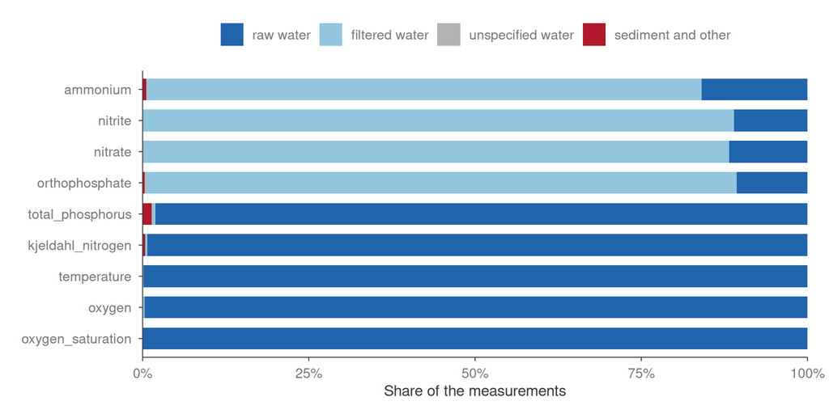

```r
fraction_name <- c(
  "23" = "raw water", "3" = "filtered water", "22" = "unspecified water"
)
naiades |>
  mutate(
    fraction = coalesce(fraction_name[code_fraction], "sediment and other"),
    fraction = factor(fraction, c(fraction_name, "sediment and other"))
  ) |>
  count(parameter, fraction) |>
  mutate(share = n / sum(n), .by = parameter) |>
  ggplot(aes(share, forcats::fct_rev(parameter), fill = fraction)) +
  geom_col(width = 0.7) +
  scale_x_continuous(labels = scales::percent, expand = c(0, 0)) +
  scale_fill_manual(values = c("#2166AC", "#92C5DE", "grey70", "#B2182B")) +
  labs(x = "Share of the measurements", y = NULL, fill = NULL) +
  theme(legend.position = "top")
```

Nutrients are mostly measured in filtered water, except total phosphorus and Kjeldahl nitrogen. The other parameters are mostly measured in raw water. We’ll keep only the main fraction analysed (e.g. filtered water for ammonium) so values are comparable.

### Units

Units used for each parameter, with their share of the measurements. Units below 0.1% of the measurements are grouped as “other”.

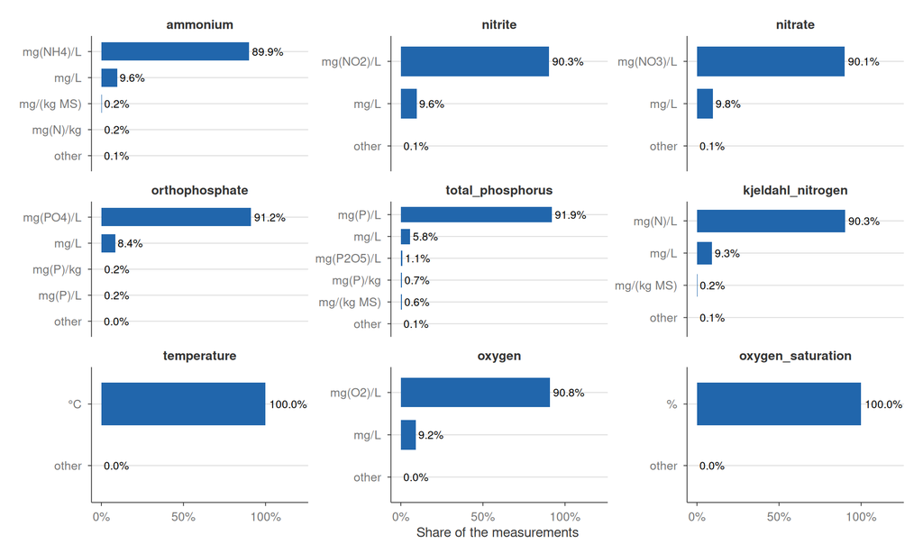

```r
naiades |>
  count(parameter, unit) |>
  mutate(share = n / sum(n), .by = parameter) |>
  mutate(unit = if_else(share < 0.001, "other", unit)) |>
  summarise(share = sum(share), .by = c(parameter, unit)) |>
  mutate(label = reorder(paste(parameter, unit, sep = "__"), share)) |>
  ggplot(aes(share, label)) +
  geom_col(fill = "#2166AC", width = 0.7) +
  geom_text(aes(label = scales::percent(share, accuracy = 0.1)), hjust = -0.1, size = 3) +
  scale_y_discrete(labels = \(x) sub(".*__", "", x)) +
  scale_x_continuous(labels = scales::percent, limits = c(0, 1.2), breaks = c(0, 0.5, 1)) +
  facet_wrap(~parameter, scales = "free_y", ncol = 3) +
  labs(x = "Share of the measurements", y = NULL)
```

A main unit always dominates, and mg/L is often the second unit, which we assume is an older notation of the main one. Measurements with other units are filtered out.

### Quantification limit

Share of the measurements below the quantification limit (remark code 10). For these measurements, the value reported is the limit itself. The median limit is given in the main unit. Temperature and oxygen are left out.

```r
main_unit <- naiades |>
  count(parameter, unit) |>
  slice_max(n, by = parameter) |>
  select(parameter, unit)
naiades_limit <- naiades |>
  filter(code_remarque %in% c("2", "7", "10"), parameter %in% parameter_name[1:6]) |>
  semi_join(main_unit, by = c("parameter", "unit")) |>
  mutate(year = as.integer(format(date, "%Y")))
naiades |>
  filter(parameter %in% parameter_name[1:6]) |>
  summarise(
    `below quantification (%)` = 100 * mean(code_remarque == "10"),
    `below detection (%)` = 100 * mean(code_remarque == "2"),
    `traces (%)` = 100 * mean(code_remarque == "7"),
    .by = parameter
  ) |>
  left_join(
    naiades_limit |>
      summarise(
        unit = unit[1],
        `median limit` = median(result),
        `2000-2004` = median(result[year <= 2004]),
        `2017-2021` = median(result[year >= 2017]),
        .by = parameter
      ),
    by = "parameter"
  ) |>
  arrange(parameter) |>
  knitr::kable(digits = c(0, 1, 1, 2, 0, 3, 3, 3))
```

| parameter | below quantification (%) | below detection (%) | traces (%) | unit | median limit | 2000-2004 | 2017-2021 |
| --- | --- | --- | --- | --- | --- | --- | --- |
| ammonium | 24.2 | 1.4 | 0.04 | mg(NH4)/L | 0.05 | 0.05 | 0.01 |
| nitrite | 20.4 | 0.6 | 0.01 | mg(NO2)/L | 0.02 | 0.05 | 0.01 |
| nitrate | 2.2 | 0.1 | 0.00 | mg(NO3)/L | 1.00 | 3.50 | 0.50 |
| orthophosphate | 19.6 | 0.4 | 0.02 | mg(PO4)/L | 0.05 | 0.10 | 0.02 |
| total_phosphorus | 11.8 | 0.5 | 0.00 | mg(P)/L | 0.05 | 0.09 | 0.01 |
| kjeldahl_nitrogen | 43.9 | 1.0 | 0.05 | mg(N)/L | 0.50 | 1.00 | 0.50 |

When there is a limit, we set the value to half the limit, as is usually done.

### Sampling frequency

Number of measurements per station and year, for the station-years with at least one measurement. Station-years with more than 24 measurements are grouped in the last bar.

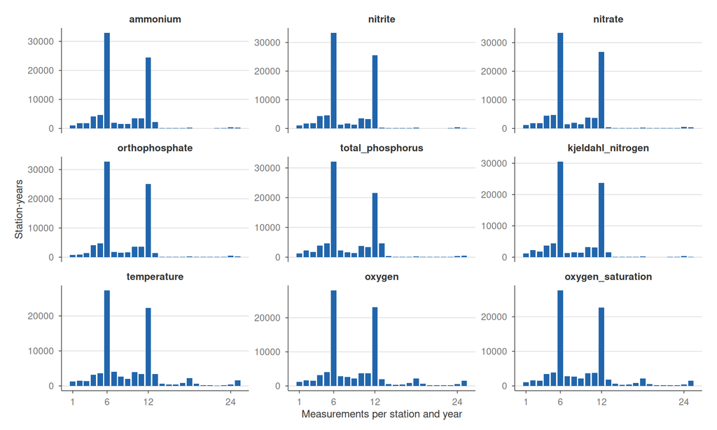

```r
naiades |>
  count(parameter, code_station, year = format(date, "%Y")) |>
  mutate(n = pmin(n, 25)) |>
  ggplot(aes(n)) +
  geom_bar(fill = "#2166AC", width = 0.8) +
  scale_x_continuous(breaks = c(1, 6, 12, 24)) +
  facet_wrap(~parameter, scales = "free_y", ncol = 3) +
  labs(x = "Measurements per station and year", y = "Station-years")
```

We see two peaks at 6 and 12 measurements per year: many stations are sampled every month or every two months. This could be useful to compute statistics (mean, variance, quantiles).

### Joint measurements

Next, we look at whether parameters are measured independently or jointly.

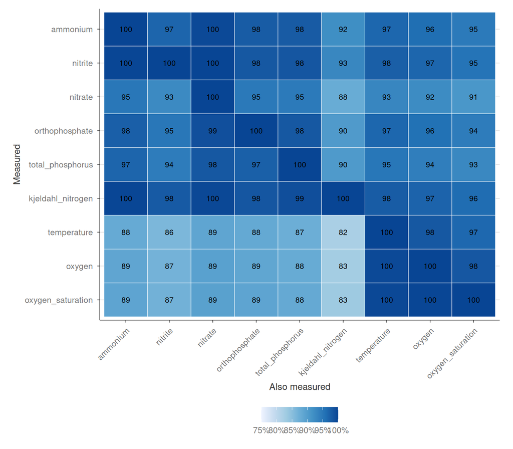

```r
naiades_sample <- naiades |>
  distinct(code_station, date, parameter) |>
  mutate(present = 1L) |>
  tidyr::pivot_wider(names_from = parameter, values_from = present, values_fill = 0L) |>
  select(all_of(unname(parameter_name)))
joint <- crossprod(as.matrix(naiades_sample))
(joint / diag(joint)) |>
  as_tibble(rownames = "parameter") |>
  tidyr::pivot_longer(-parameter, names_to = "parameter_also", values_to = "share") |>
  mutate(across(c(parameter, parameter_also), \(x) factor(x, parameter_name))) |>
  ggplot(aes(parameter_also, forcats::fct_rev(parameter), fill = share)) +
  geom_tile(color = "white") +
  geom_text(aes(label = round(100 * share)), size = 3) +
  scale_fill_distiller(
    palette = "Blues", direction = 1, labels = scales::percent,
    limits = c(0.75, 1), oob = scales::squish
  ) +
  labs(x = "Also measured", y = "Measured", fill = NULL) +
  theme(axis.text.x = element_text(angle = 45, hjust = 1))
```

Most parameters are measured jointly. The table below gives the share of samples in which all nutrients are measured, and in which all parameters are measured.

```r
naiades_sample |>
  mutate(nutrients = rowSums(pick(1:6)), all = rowSums(pick(1:9))) |>
  summarise(
    samples = n(),
    `all nutrients (%)` = 100 * mean(nutrients == 6),
    `all parameters (%)` = 100 * mean(all == 9)
  ) |>
  knitr::kable(digits = 1, format.args = list(big.mark = ","))
```

| samples | all nutrients (%) | all parameters (%) |
| --- | --- | --- |
| 843,931 | 74.6 | 72.6 |

### Parameter distributions

Distribution of the quantified measurements after cleaning.

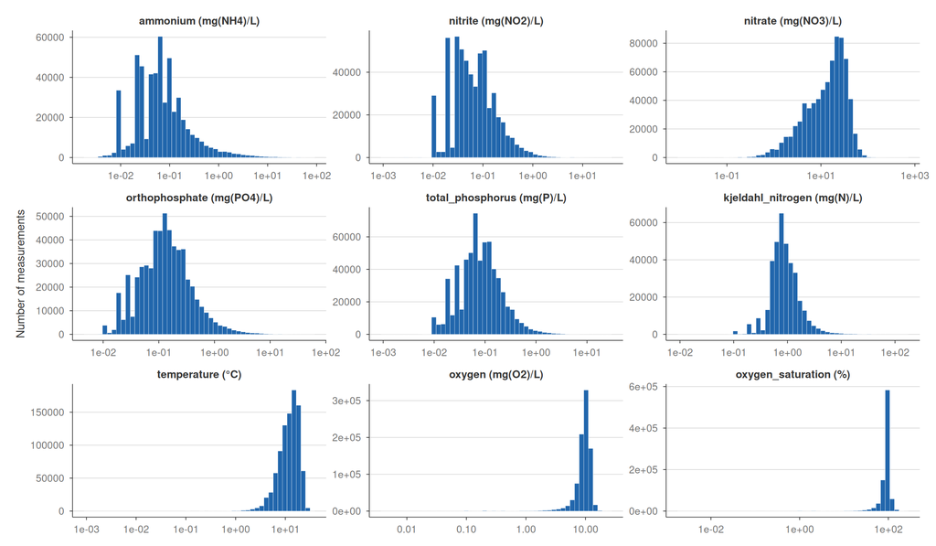

```r
naiades_clean <- tar_read(naiades_clean) |>
  mutate(parameter = factor(parameter_name[code_parametre], parameter_name)) |>
  select(-unit) |>
  left_join(main_unit, by = "parameter")
naiades_clean |>
  filter(!below_limit) |>
  ggplot(aes(value)) +
  geom_histogram(bins = 50, fill = "#2166AC", color = "white", linewidth = 0.1) +
  scale_x_log10() +
  facet_wrap(~ forcats::fct_reorder(paste0(parameter, " (", unit, ")"), as.integer(parameter)), scales = "free") +
  labs(x = NULL, y = "Number of measurements")
```

Spatial distributions of parameter values, averaged over the years.

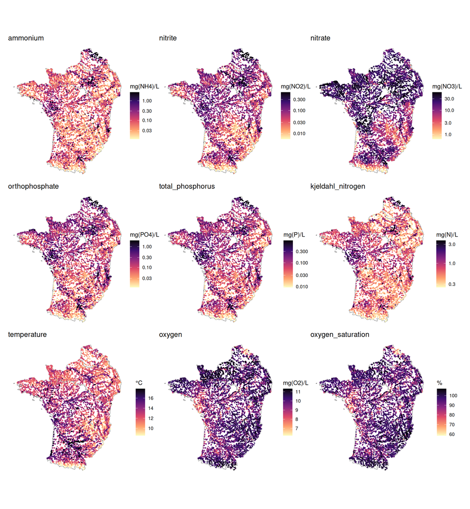

```r
basin_kept <- tar_read(basin) |>
  filter(district %in% tar_read(params)$district_kept)
station_mean <- naiades_clean |>
  summarise(value = mean(value), n = n(), .by = c(parameter, code_station)) |>
  filter(n >= 12) |>
  inner_join(tar_read(naiades_station), by = "code_station") |>
  sf::st_as_sf()
lapply(parameter_name, \(p) {
  station <- arrange(filter(station_mean, parameter == p), value)
  unit <- main_unit$unit[main_unit$parameter == p]
  ggplot() +
    geom_sf(data = basin_kept, fill = NA, color = "grey40") +
    geom_sf(data = station, aes(color = value), size = 0.4) +
    scale_color_viridis_c(
      name = unit, option = "magma", direction = -1,
      transform = if (p %in% parameter_name[1:6]) "log10" else "identity",
      limits = quantile(station$value, c(0.01, 0.99)), oob = scales::squish
    ) +
    labs(title = p) +
    theme_void()
}) |>
  patchwork::wrap_plots(ncol = 3)
```

## Preprocessing the data

From here on, the unit is the station-year: the mean of each parameter per station and year (log10 for the nutrients). A station-year is kept when each of the nine parameters has at least 4 measurements spread over at least 3 seasons (winter December-February, spring, summer, autumn), so that the mean is not driven by a single season.

### Correlation between parameters

Pearson correlation between the station-year means of the parameters. This information may be useful to understand the link between the input variables.

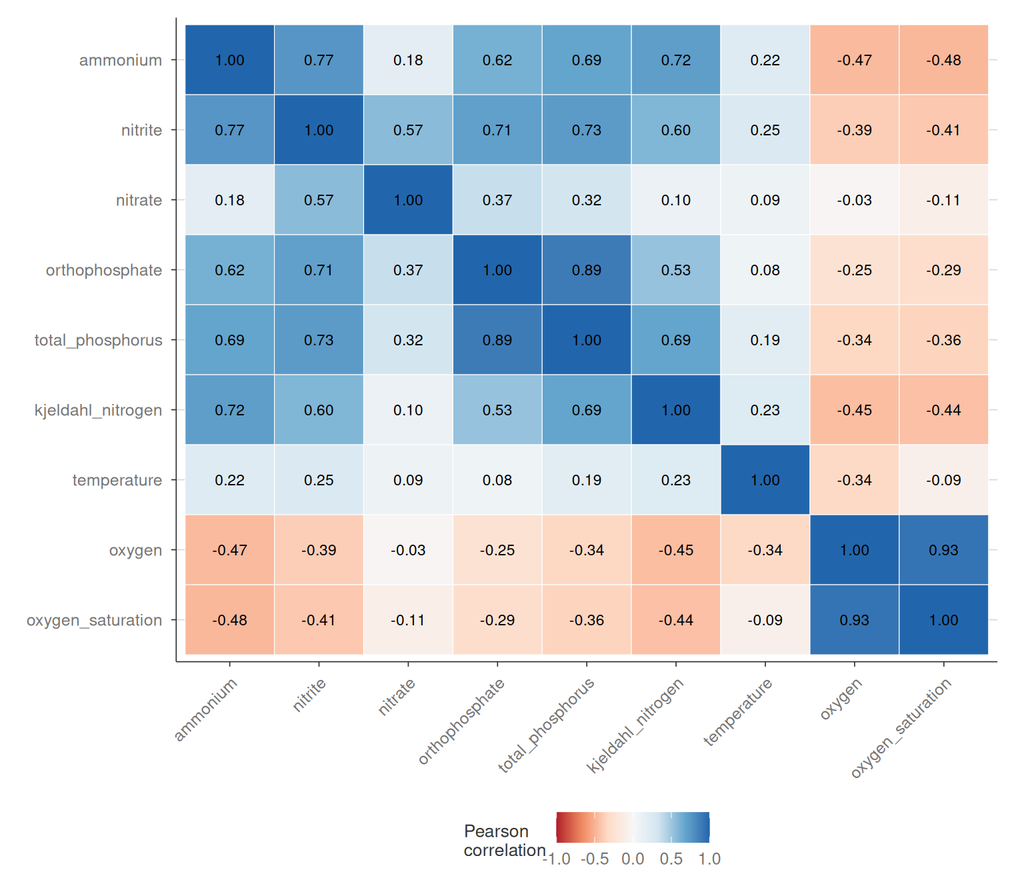

```r
station_year <- tar_read(naiades_station_year)
cor(station_year[unname(parameter_name)]) |>
  as_tibble(rownames = "parameter") |>
  tidyr::pivot_longer(-parameter, names_to = "parameter_with", values_to = "correlation") |>
  mutate(across(c(parameter, parameter_with), \(x) factor(x, parameter_name))) |>
  ggplot(aes(parameter_with, forcats::fct_rev(parameter), fill = correlation)) +
  geom_tile(color = "white") +
  geom_text(aes(label = sprintf("%.2f", correlation)), size = 3) +
  scale_fill_distiller(palette = "RdBu", direction = 1, limits = c(-1, 1)) +
  labs(x = NULL, y = NULL, fill = "Pearson\ncorrelation") +
  theme(axis.text.x = element_text(angle = 45, hjust = 1))
```

We have many parameters, some of them strongly correlated, so a PCA is a natural way to build a synthetic indicator of water quality.

### Using a PCA to build a water quality index

PCA of the same station-year means, standardised.

```r
naiades_pca <- tar_read(water_quality_pca) # PC1 signed to increase with water quality
```

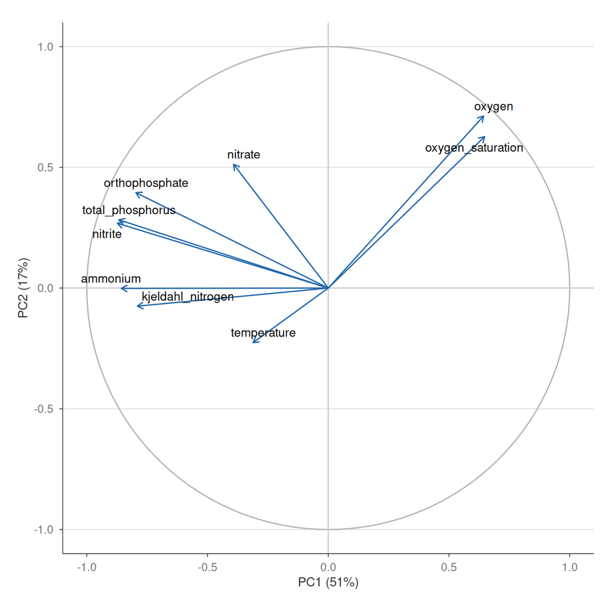

```r
variance <- 100 * naiades_pca$sdev^2 / sum(naiades_pca$sdev^2)
loading <- cor(station_year[unname(parameter_name)], naiades_pca$x[, 1:2]) |>
  as_tibble(rownames = "parameter")
ggplot(loading, aes(PC1, PC2)) +
  annotate("path", x = cos(seq(0, 2 * pi, length.out = 200)), y = sin(seq(0, 2 * pi, length.out = 200)), color = "grey70") +
  geom_hline(yintercept = 0, color = "grey80") +
  geom_vline(xintercept = 0, color = "grey80") +
  geom_segment(aes(x = 0, y = 0, xend = PC1, yend = PC2),
    arrow = arrow(length = unit(0.2, "cm")), color = "#2166AC"
  ) +
  ggrepel::geom_text_repel(aes(label = parameter), size = 3.5) +
  coord_equal(xlim = c(-1, 1), ylim = c(-1, 1)) +
  labs(
    x = sprintf("PC1 (%.0f%%)", variance[1]),
    y = sprintf("PC2 (%.0f%%)", variance[2])
  )
```

We see that all nutrients go in the same direction, opposite to oxygen. In sum, PC1 represents a synthetic index of water quality: higher values mean fewer nutrients (nitrate, phosphate, etc.) and higher oxygen concentration. In what follows, we will use this axis as an indicator of water quality.

**NoteReading PC1**

Throughout the notebook, a higher PC1 means a better water quality. A positive effect of PC1 on a species therefore means that the species is more present where the water is clean, and a negative effect that it is more present where the water is polluted.

Below are the values of PC1 and PC2 at each station (averaged over the years).

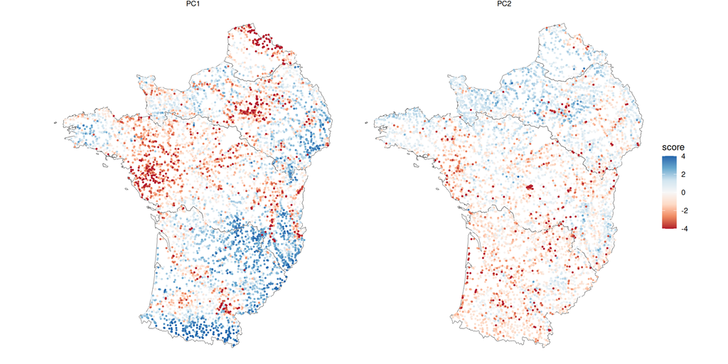

```r
station_score <- station_year |>
  bind_cols(as_tibble(naiades_pca$x[, 1:2]))
station_score |>
  summarise(across(c(PC1, PC2), mean), .by = code_station) |>
  inner_join(tar_read(naiades_station), by = "code_station") |>
  sf::st_as_sf() |>
  tidyr::pivot_longer(c(PC1, PC2), names_to = "axis", values_to = "score") |>
  arrange(abs(score)) |>
  ggplot() +
  geom_sf(data = basin_kept, fill = NA, color = "grey40") +
  geom_sf(aes(color = score), size = 0.5) +
  scale_color_distiller(palette = "RdBu", direction = 1, limits = c(-4, 4), oob = scales::squish) +
  facet_wrap(~axis) +
  theme_void()
```

Next, we have a look at the temporal trend of this water quality index. We plot two trends, one keeping all stations available, the other keeping only stations for which we have a measurement each year so we can check that the trend is not influenced by changing the station set.

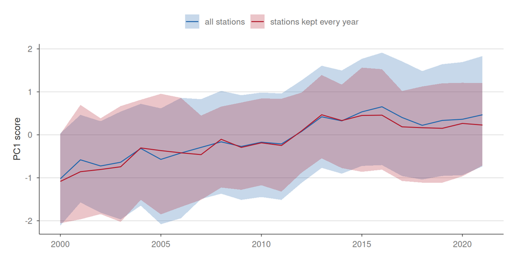

```r
station_full <- station_score |>
  filter(n_distinct(year) == 22, .by = code_station)
bind_rows(
  `all stations` = station_score,
  `stations kept every year` = station_full,
  .id = "stations"
) |>
  summarise(
    median = median(PC1), lower = quantile(PC1, 0.25), upper = quantile(PC1, 0.75),
    .by = c(stations, year)
  ) |>
  ggplot(aes(year, median, color = stations, fill = stations)) +
  geom_ribbon(aes(ymin = lower, ymax = upper), alpha = 0.25, color = NA) +
  geom_line() +
  scale_color_manual(values = c("#2166AC", "#B2182B"), aesthetics = c("color", "fill")) +
  labs(x = NULL, y = "PC1 score", color = NULL, fill = NULL) +
  theme(legend.position = "top")
```

The rise of PC1 coincides with the fall of the quantification limits around 2010. But the rise remains when all limits are set to a common value over the years, so it reflects a real improvement of water quality.

## Matching water quality to the fishing operations

### Fishing operations match NAIADES stations

For each fishing operation (station-year) we need a water quality value. This means predicting water quality (PC1) at unobserved station-years. Luckily most fish sites are also NAIADES stations (that is, they share the Sandre code), but water quality is not always measured in the year of the operation.

We plot below each fish site coloured by whether water quality is available at all visits, in some of them, only in other years, or not at all.

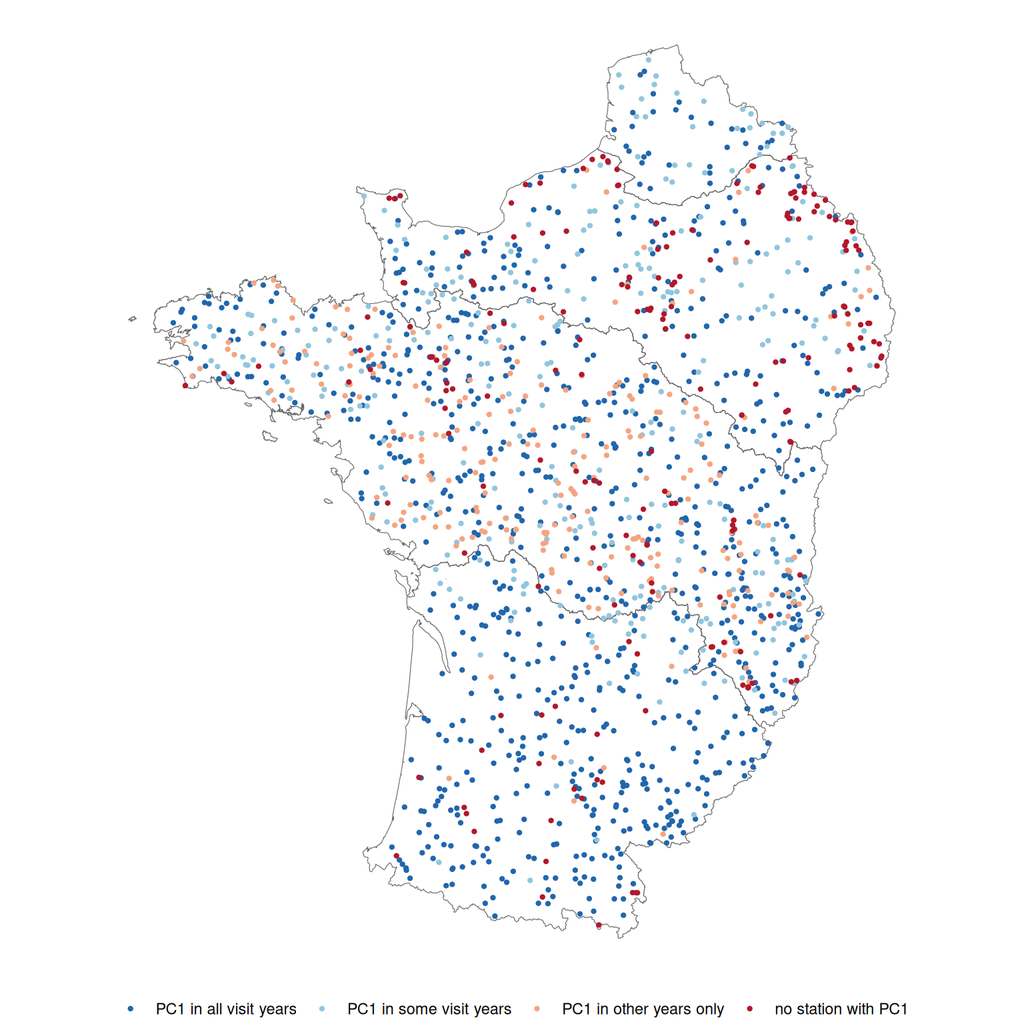

```r
water_quality <- tar_read(water_quality)
tar_read(dam_visit) |>
  mutate(
    station = sandre_code %in% water_quality$code_station,
    same_year = paste(sandre_code, year) %in% paste(water_quality$code_station, water_quality$year)
  ) |>
  summarise(
    longitude = longitude[1], latitude = latitude[1],
    naiades = case_when(
      all(same_year) ~ "PC1 in all visit years",
      any(same_year) ~ "PC1 in some visit years",
      any(station) ~ "PC1 in other years only",
      .default = "no station with PC1"
    ),
    .by = site
  ) |>
  mutate(naiades = factor(naiades, c(
    "PC1 in all visit years", "PC1 in some visit years", "PC1 in other years only",
    "no station with PC1"
  ))) |>
  arrange(naiades) |>
  sf::st_as_sf(coords = c("longitude", "latitude"), crs = 4326) |>
  ggplot() +
  geom_sf(data = basin_kept, fill = NA, color = "grey40") +
  geom_sf(aes(color = naiades), size = 0.8) +
  scale_color_manual(values = c("#2166AC", "#92C5DE", "#F4A582", "#B2182B")) +
  labs(color = NULL) +
  theme_void() +
  theme(legend.position = "bottom")
```

Only a minority of operations have no information on water quality (in any year), represented by the red dots above. We choose to remove these operations, keeping only stations for which we have water quality data and so where we can easily infer water quality in the missing years.

### Inferring missing water quality values

#### The model

PC1 is modelled with INLA from the station-year scores. For station $s$ in year $t$,
$$\text{PC1}_{s,t} = \beta_0 + \omega(x_s) + \gamma_t + u_s + \varepsilon_{s,t},$$
with

- $\beta_0$ the intercept;
- $\omega(x_s)$ a Matérn spatial field (SPDE) at the location $x_s$ of the station, constant over time, which captures that nearby stations have similar water quality;
- $\gamma_t$ a year effect following an AR1 process, shared by all stations, which captures the overall trend;
- $u_s$ an iid station effect, which captures what is specific to each station;
- $\varepsilon_{s,t}$ the Gaussian residual.

#### Cross-validation

We check the predictions with two cross-validations, each with 10 random folds, each fold predicted by the model fitted on the others. The model is the same in both; what differs is what is held out, and therefore which terms can inform the prediction:

- **station-years:** single station-years are held out, and the station keeps its other years. Its station effect $u_s$ is estimated from these other years, so the prediction is $\hat\beta_0 + \hat\omega(x_s) + \hat\gamma_t + \hat u_s$. This is the case of a fishing operation at a NAIADES station, in a year without measurement.
- **stations:** all the years of the held-out stations are left out. Their station effect is unknown, so it is set to its prior mean of 0 and the prediction is $\hat\beta_0 + \hat\omega(x_s) + \hat\gamma_t$: it relies on the neighbouring stations only, through the spatial field. This is the case of a fish site without a NAIADES station.

```r
tar_read(water_quality_cv) |>
  summarise(
    rmse = sqrt(mean((PC1 - mean)^2)),
    r2 = cor(PC1, mean)^2,
    .by = type
  ) |>
  knitr::kable(digits = 2)
```

| type | rmse | r2 |
| --- | --- | --- |
| station | 1.44 | 0.55 |
| station_year | 0.79 | 0.86 |

Observed against predicted PC1 of the held-out station-years (number of station-years per cell, log scale); the dashed line is the 1:1 line.

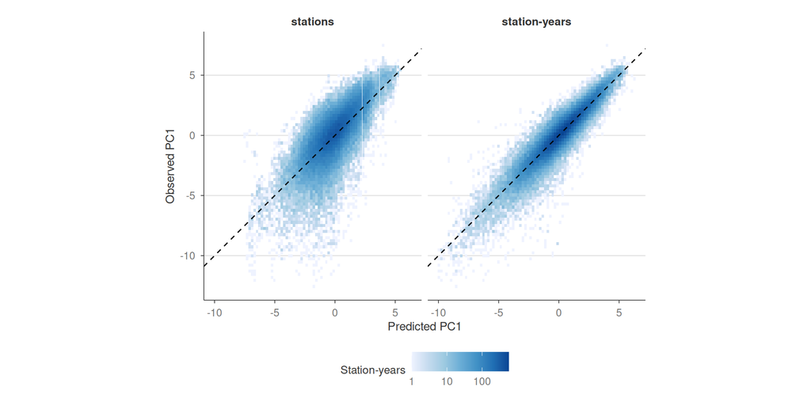

```r
tar_read(water_quality_cv) |>
  ggplot(aes(mean, PC1)) +
  geom_bin_2d(bins = 80) +
  geom_abline(linetype = "dashed") +
  scale_fill_distiller(palette = "Blues", direction = 1, transform = "log10") +
  facet_wrap(~type, labeller = as_labeller(c(station = "stations", station_year = "station-years"))) +
  coord_equal() +
  labs(x = "Predicted PC1", y = "Observed PC1", fill = "Station-years")
```

The model is quite good at predicting missing values when the station effect is known, which is our case (R² 0.86), but much weaker without it (R² 0.55).

### Water quality at the fishing operations

We now fit the model on all the station-years and use it to give a water quality value to each fishing operation (target `water_quality_visit`). An operation gets the value predicted by the model at its station, in the year of the operation.

Some operations fall in a year where PC1 was measured at the station. We could use the measured value for these and the predicted value for the others, but we use the predicted value for all operations, for two reasons:

- a measured value is the mean of only 4 to 12 samples, so it is a noisy estimate of the water quality of that year, and noise in a covariate weakens its estimated effect; the predicted value is smoothed by the model;
- mixing measured and predicted values would give some operations a noisier value than others, depending on where and when stations were monitored.

The predicted value also leans on the station effect, which reflects the water quality of the station over several years, the time scale to which fish presence most likely responds. The price is that a real deviation of a given year (e.g. an unusually polluted year) is partly smoothed out. In practice the choice matters little: where PC1 was measured, measured and predicted values are highly correlated (0.95).

Operations at the 203 sites without a NAIADES station are dropped, which leaves 5,550 of the 5,929 operations.

PC1 at the fishing operations of three years covering the period (posterior mean).

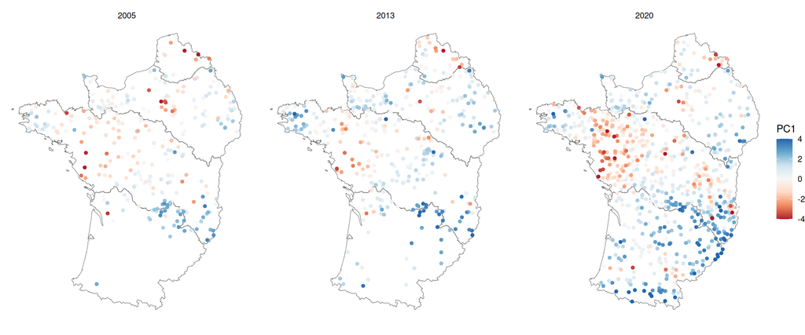

```r
tar_read(water_quality_visit) |>
  filter(year %in% c(2005, 2013, 2020)) |>
  inner_join(distinct(water_quality, code_station, X, Y), by = "code_station") |>
  mutate(X = 1000 * X, Y = 1000 * Y) |>
  arrange(abs(mean)) |>
  sf::st_as_sf(coords = c("X", "Y"), crs = 2154) |>
  ggplot() +
  geom_sf(data = basin_kept, fill = NA, color = "grey40") +
  geom_sf(aes(color = mean), size = 1.3) +
  scale_color_distiller(palette = "RdBu", direction = 1, limits = c(-4, 4), oob = scales::squish) +
  facet_wrap(~year) +
  labs(color = "PC1") +
  theme_void()
```

## Presence models with dams and water quality

We use the presence models of D12 (continuum position, sampling effort, site and year effects, spatial field), fitted on the operations with a predicted PC1. PC1 is centred and scaled over these operations, so its effect is per standard deviation. We compare four ways to include the two stressors:

- **dam:** dam accumulation only (D12 model)
- **quality:** PC1 instead of dam accumulation
- **additive:** dam accumulation + PC1
- **interaction:** dam accumulation × PC1

### Model comparison on the trout

The four models are first compared on the brown trout, a species known to be sensitive to water quality. Each model is fitted with and without spatial field.

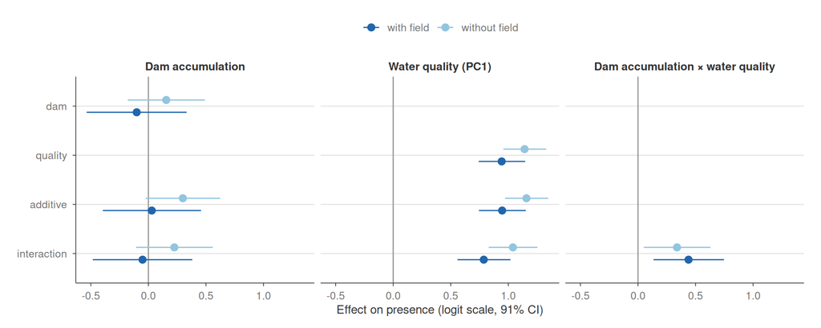

```r
setting <- tar_read(stressor_setting)
fits <- tar_read(stressor_model)
purrr::map_dfr(seq_along(fits), \(i) {
  fits[[i]]$summary.fixed |>
    as_tibble(rownames = "term") |>
    filter(term %in% c("accumulation", "PC1", "accumulation:PC1")) |>
    transmute(
      model = setting$model[i],
      field = if_else(setting$field[i], "with field", "without field"),
      term, mean, lower = `0.045quant`, upper = `0.955quant`
    )
}) |>
  mutate(
    model = factor(model, rev(unique(setting$model))),
    term = factor(term, c("accumulation", "PC1", "accumulation:PC1"),
      c("Dam accumulation", "Water quality (PC1)", "Dam accumulation × water quality"))
  ) |>
  ggplot(aes(mean, model, color = field)) +
  geom_vline(xintercept = 0, color = "grey60") +
  geom_pointrange(aes(xmin = lower, xmax = upper), position = position_dodge(width = 0.5)) +
  scale_color_manual(values = c("#2166AC", "#92C5DE")) +
  facet_wrap(~term) +
  labs(x = "Effect on presence (logit scale, 91% CI)", y = NULL, color = NULL) +
  theme(legend.position = "top")
```

WAIC of the models (lower is better).

```r
tibble(
  model = setting$model,
  field = if_else(setting$field, "with field", "without field"),
  waic = purrr::map_dbl(fits, \(fit) fit$waic$waic)
) |>
  tidyr::pivot_wider(names_from = field, values_from = waic) |>
  knitr::kable(digits = 1)
```

| model | with field | without field |
| --- | --- | --- |
| dam | 3845.7 | 3903.8 |
| quality | 3804.1 | 3831.9 |
| additive | 3804.7 | 3829.5 |
| interaction | 3801.2 | 3827.1 |

Unsurprisingly, trout presence rises strongly with water quality, while dam accumulation has no effect. The interaction between dams and water quality is positive: dams are more harmful where water quality is poor. All models with PC1 have a much lower WAIC than the dam model, and the interaction model is slightly better than the others. The estimates barely change without the spatial field. In a side check, adding the station-year mean temperature left the PC1 effect unchanged and did not improve WAIC.

**NoteReading the interaction**

With the interaction, the dam effect depends on water quality: it is the dam effect plus the interaction times PC1. For the trout, the dam effect is close to zero at average water quality and the interaction is positive: dams lower trout presence where the water is polluted (low PC1), but not where it is clean.

### All species

The interaction model with spatial field, the best for the trout, is fitted for all the species (target `species_stressor_model`). Species are ordered by their water quality effect.

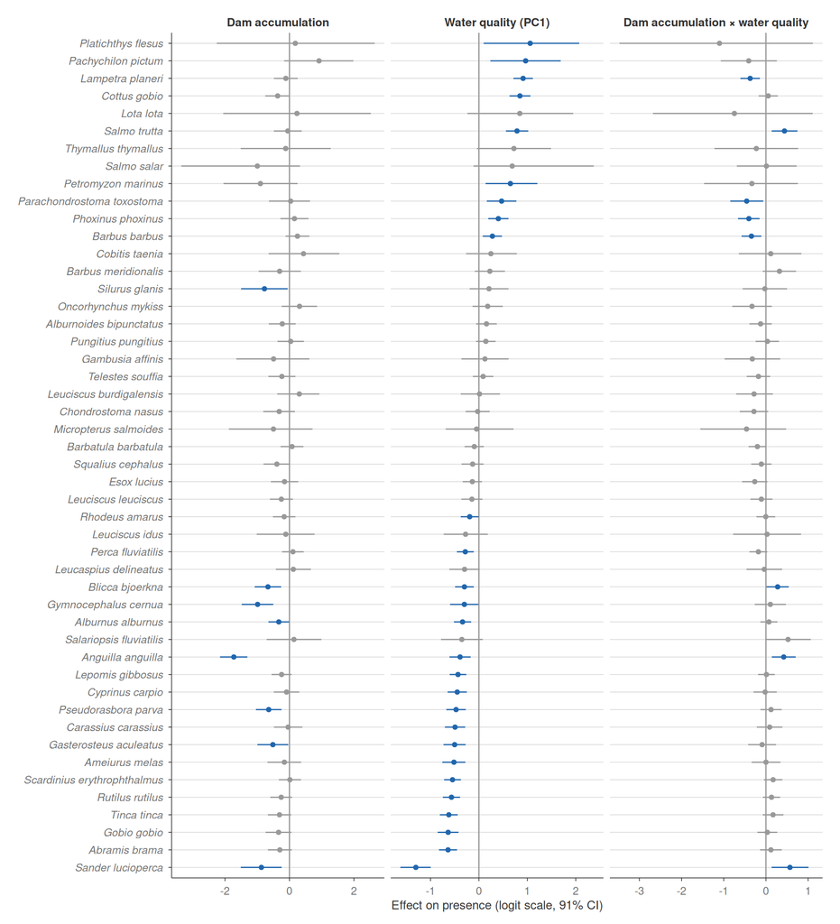

```r
species_effect <- tar_read(species_stressor_model) |>
  purrr::map_dfr(\(fit) {
    fit$summary.fixed |>
      as_tibble(rownames = "term") |>
      filter(term %in% c("accumulation", "PC1", "accumulation:PC1")) |>
      transmute(species = fit$species, term, mean, lower = `0.045quant`, upper = `0.955quant`)
  })
species_order <- species_effect |>
  filter(term == "PC1") |>
  arrange(mean) |>
  pull(species)
species_effect |>
  mutate(
    species = factor(species, species_order),
    term = factor(term, c("accumulation", "PC1", "accumulation:PC1"),
      c("Dam accumulation", "Water quality (PC1)", "Dam accumulation × water quality")),
    credible = lower > 0 | upper < 0
  ) |>
  ggplot(aes(mean, species, color = credible)) +
  geom_vline(xintercept = 0, color = "grey60") +
  geom_pointrange(aes(xmin = lower, xmax = upper), size = 0.2) +
  scale_color_manual(values = c(`TRUE` = "#2166AC", `FALSE` = "grey60"), guide = "none") +
  facet_wrap(~term, scales = "free_x") +
  labs(x = "Effect on presence (logit scale, 91% CI)", y = NULL) +
  theme(axis.text.y = element_text(face = "italic"))
```

We see that water quality is the main stressor as it is much more often credible than dam accumulation. Water quality can have a positive or negative effect, meaning that some species are more present where water quality is poor. We expect these species to be tolerant to toxicity/low oxygen. To check this, we next compare the estimated effect of water quality on species with their known tolerance.

### Comparison with the known tolerance of the species

To check the water quality effects independently of our models, we compare them with the tolerance classes of the species from the freshwaterecology.info database (Schmidt-Kloiber and Hering 2015). We take them from the `aspe` R package of the OFB (table `data_traits_bio`, https://github.com/PascalIrz/aspe), which ships an export of the database made in July 2023 (target `fish_trait`). The classes are based on expert knowledge, not on measurements. Each species is classed as intolerant, intermediate or tolerant to the degradation of the general water quality, to low oxygen and to toxic substances.

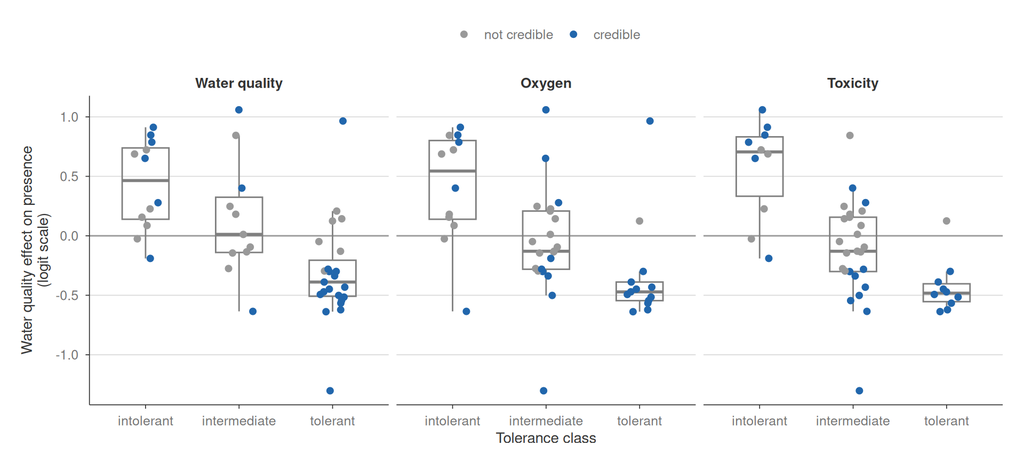

```r
tolerance_label <- c(
  `water quality tolerance` = "Water quality", `oxygen tolerance` = "Oxygen",
  `toxicity tolerance` = "Toxicity"
)
species_effect |>
  filter(term == "PC1") |>
  inner_join(tar_read(fish_trait), by = c(species = "esp_nom_latin")) |>
  tidyr::pivot_longer(all_of(names(tolerance_label)), names_to = "trait", values_to = "class") |>
  filter(!is.na(class)) |>
  mutate(
    trait = factor(tolerance_label[trait], tolerance_label),
    class = factor(class, c("intol", "im", "tol"), c("intolerant", "intermediate", "tolerant")),
    credible = lower > 0 | upper < 0
  ) |>
  ggplot(aes(class, mean)) +
  geom_hline(yintercept = 0, color = "grey60") +
  geom_boxplot(outlier.shape = NA, fill = NA, color = "grey50", width = 0.5) +
  geom_point(aes(color = credible), position = position_jitter(width = 0.15, seed = 1), size = 1.8) +
  scale_color_manual(values = c(`TRUE` = "#2166AC", `FALSE` = "grey60"), labels = c(`TRUE` = "credible", `FALSE` = "not credible")) +
  facet_wrap(~trait) +
  labs(x = "Tolerance class", y = "Water quality effect on presence\n(logit scale)", color = NULL) +
  theme(legend.position = "top")
```

The estimated water quality effects mostly agree with the known tolerance, which is reassuring: it suggests that our model captures a real effect of water quality rather than an unobserved confounding variable.

The main exception, *Pachychilon pictum*, is classed tolerant but is more present where water quality is good. It is a rare species introduced from the Balkans and found mostly in a few rivers of the Adour-Garonne basin, so its effect likely reflects where it was introduced rather than a preference for clean water.

## Conclusion

- PC1 of the NAIADES parameters is a good water quality index: it opposes nutrients to oxygen and explains about half of the variance.
- The space-time model predicts PC1 well at the fishing operations that are NAIADES stations, including in years without measurement.
- Water quality shapes species presence more than dams do, with sensitive species favoured by good water quality and tolerant lowland species by poor water quality.
- The interaction between dams and water quality is weak and inconsistent across species, so we keep the additive model (dams + water quality) for the food web structure.

**To go further.** The uncertainty of the predicted PC1 is not propagated to the presence models (but it is small at the fishing operations); the annual mean temperature is a poor measure of thermal stress, we could test summer maxima.

## References

Schmidt-Kloiber, Astrid, and Daniel Hering. 2015. “Www.freshwaterecology.info – an Online Tool That Unifies, Standardises and Codifies More Than 20,000 European Freshwater Organisms and Their Ecological Preferences.” *Ecological Indicators* 53 (June): 271–82. https://doi.org/10.1016/j.ecolind.2015.02.007.